# Lab 02 - Plastic waste

Fiona Wang

Jan-28-2025

## Load packages and data

```r
library(tidyverse)
```

```r
plastic_waste <- read.csv("data/plastic-waste.csv")
```

## Exercises

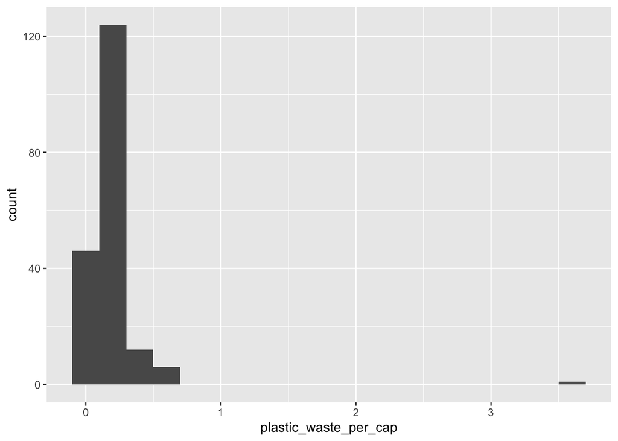

```r
ggplot(data = plastic_waste, aes(x = plastic_waste_per_cap)) +
  geom_histogram(binwidth = 0.2)
```

There is one country that stands out, let’s filter to find this country!

```r
plastic_waste %>%
  filter(plastic_waste_per_cap > 3.5)
```

```
##   code              entity     continent year gdp_per_cap plastic_waste_per_cap
## 1  TTO Trinidad and Tobago North America 2010    31260.91                   3.6
##   mismanaged_plastic_waste_per_cap mismanaged_plastic_waste coastal_pop
## 1                             0.19                    94066     1358433
##   total_pop
## 1   1341465
```

It is Trinidad and Tobago from North America. I didn’t expect this result, mainly because it is a country that I am not familiar with. It seems like they have high consumption of single-use plastics and limited recycling infrastructure.

### Exercise 1 Histogram

There weren’t a lot of countries reported on Oceania and South America, so they seem to have less plastic waste. North America has the outlier (Trinidad and Tobago). Most countries’ plastic waste per capita is between 0 to 0.5.The tallest bars among these graphs are 0.0-0.2 and 0.2-0.4.

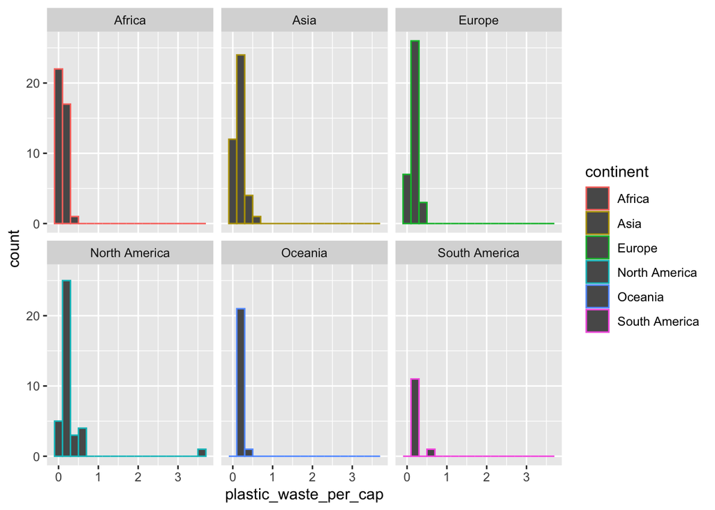

```r
ggplot(data = plastic_waste, aes(x = plastic_waste_per_cap, color = continent)) +
  geom_histogram(binwidth = 0.2) +
  facet_wrap(~continent, ncol = 3)
```

Another way of visualizing is using density plots.

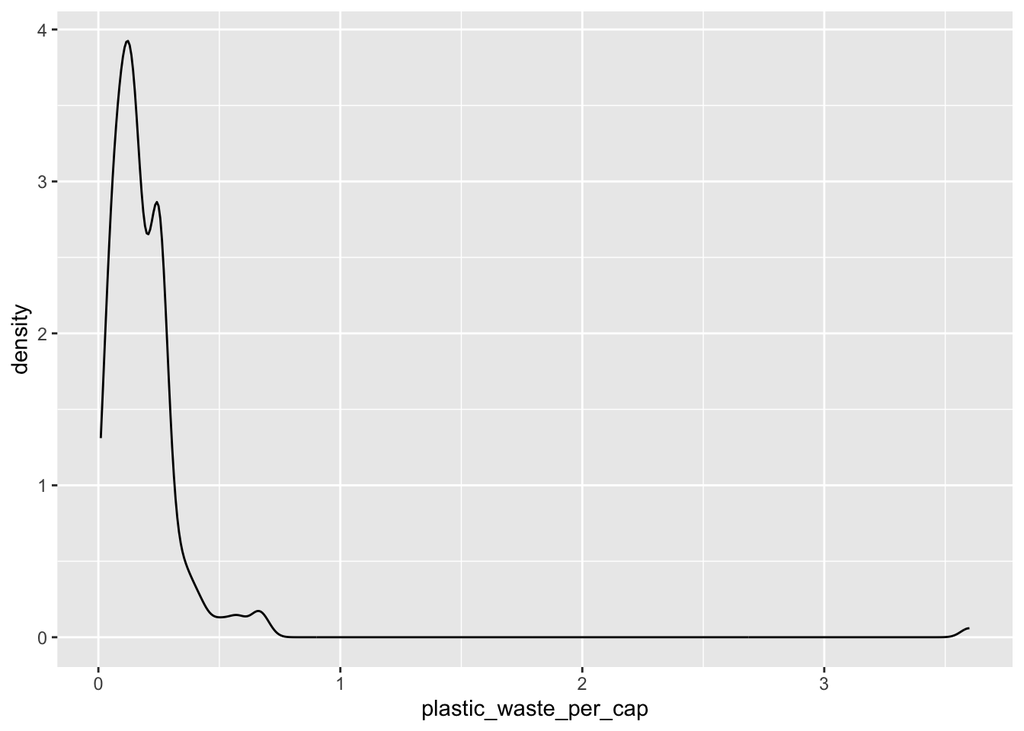

```r
ggplot(data = plastic_waste, aes(x = plastic_waste_per_cap)) +
  geom_density()
```

Compare distributions across continent by coloring density curves by continent.

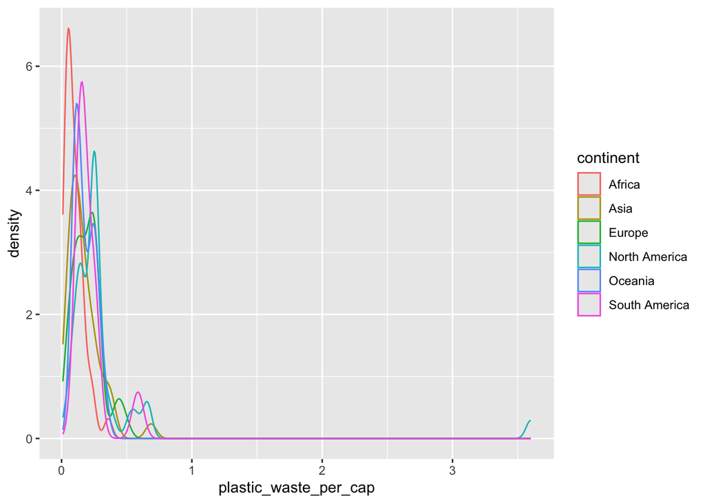

```r
ggplot(data = plastic_waste, mapping = aes(x=plastic_waste_per_cap,
       color = continent)) +
  geom_density()
```

Fill the curves of the density graph and adjust the transparency.

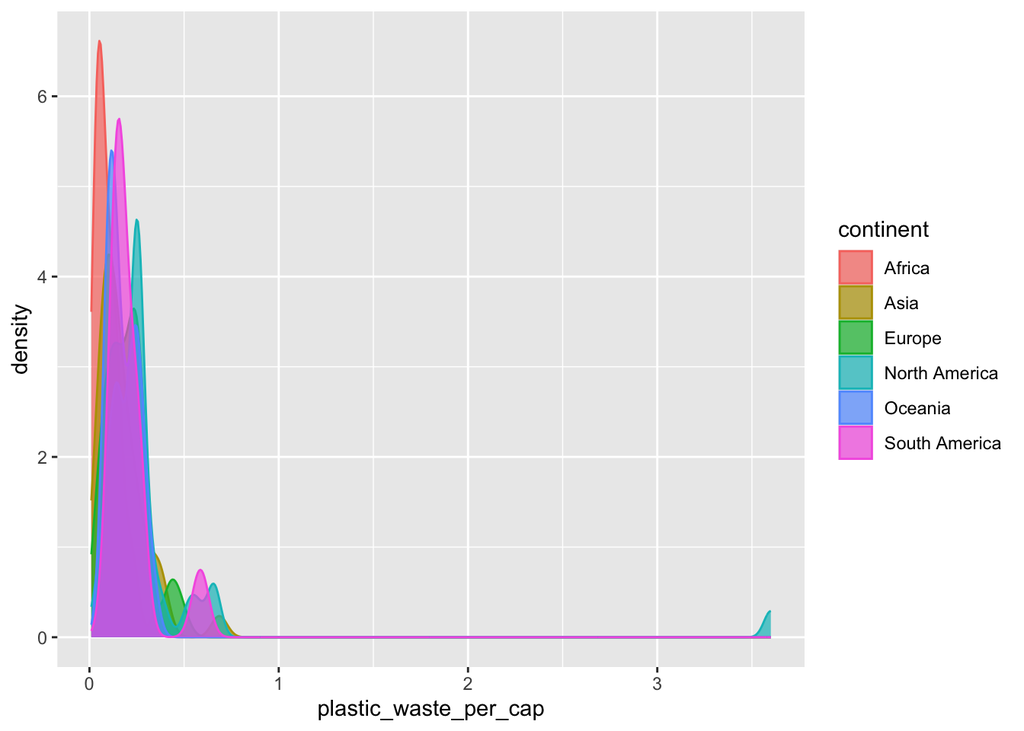

```r
ggplot(data = plastic_waste,
       mapping = aes(x = plastic_waste_per_cap, color = continent,
                     fill = continent)) +
  geom_density(alpha = 0.7)
```

### Exercise 2 Recreate density plot

To compare between mapping and setting/geom, I am trying out the following two ways. First, let’s use geom_density to define color and fill, and we use mapping to define alpha. The second way is to put color and fill in mapping while defining alpha in the setting/geom.

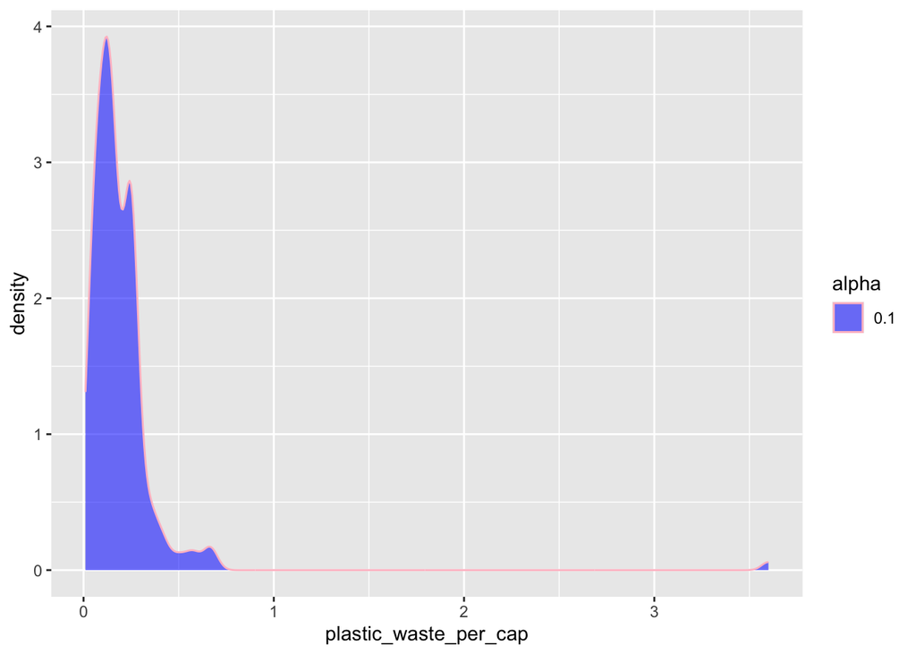

```r
#The first way
ggplot(data = plastic_waste,
       mapping = aes(x = plastic_waste_per_cap, alpha = 0.1)) +
  geom_density(color = "pink", fill = "blue")
```

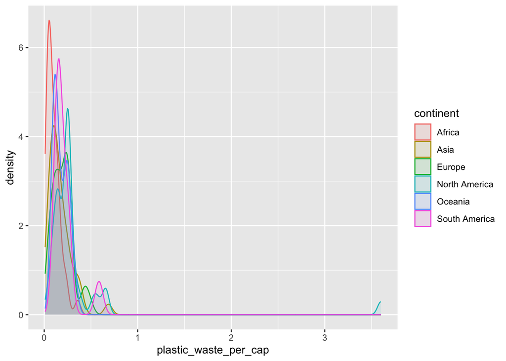

```r
#The second way
ggplot(data = plastic_waste,
       mapping = aes(x = plastic_waste_per_cap,
                     color = continent, fill = continent)) +
  geom_density(alpha = 0.1)
```

Another way to visualize is using box plots.

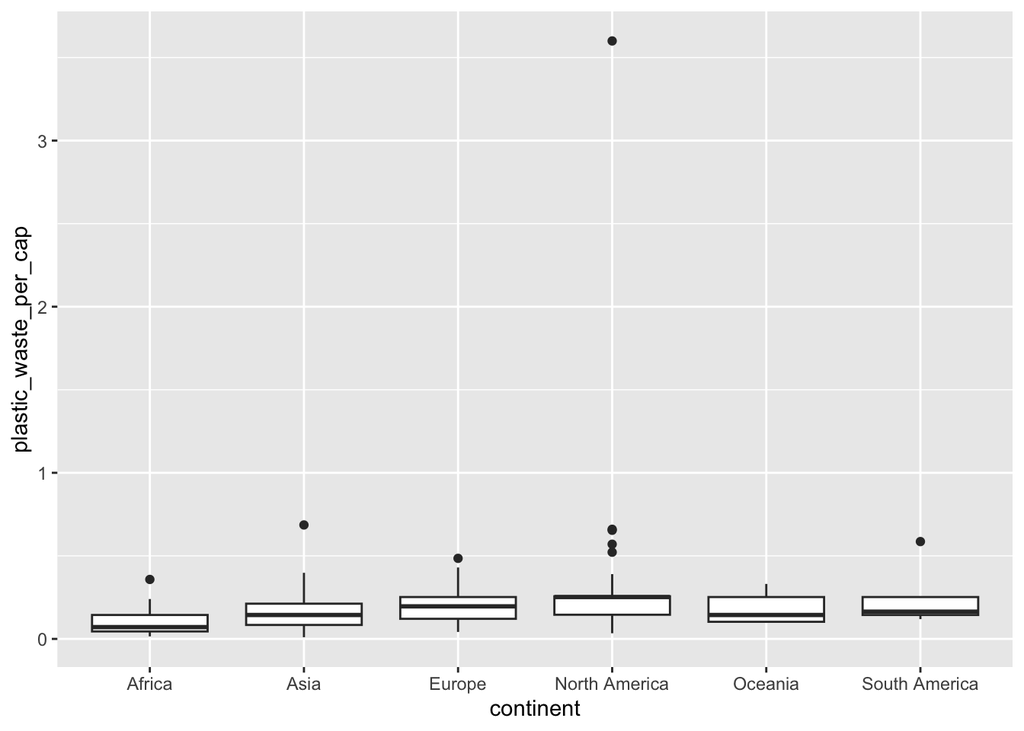

```r
ggplot(data = plastic_waste,
       mapping = aes(x = continent, y = plastic_waste_per_cap)) +
  geom_boxplot()
```

### Exercise 3 Violin

Both boxplot and violin plot give us outliers. The boxplot gives us the median and quartiles that a violin plot doesn’t. A violin plot can give you the distribution of each continent which the boxplot doesn’t.

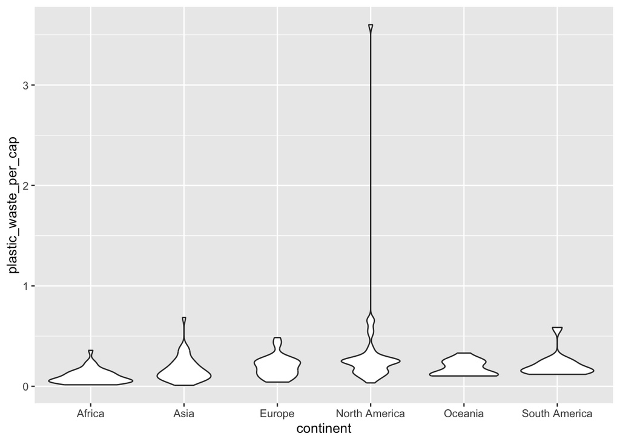

```r
ggplot(data = plastic_waste,
       mapping = aes(x = continent, y = plastic_waste_per_cap)) +
  geom_violin()
```

### Exercise 4 Scatterplot

4.1. In general, it seems like the more plastic waste per capita, the more mismanaged plastic waste per capita. If there is a linear relationship, it is a positive one.

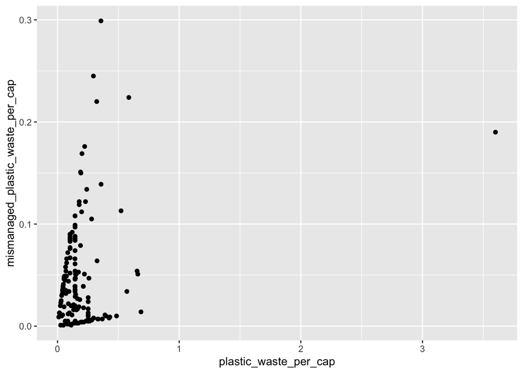

```r
ggplot(data = plastic_waste,
       mapping = aes(x = plastic_waste_per_cap,
                     y = mismanaged_plastic_waste_per_cap)) +
  geom_point()
```

4.2. As we see from the plot below, all continent has a positive relationship between plastic waste per capita and mismanaged plastic waste per capita. Some have steeper slopes: Asia and Africa, whereas some have smaller slopes:North America, Europe).

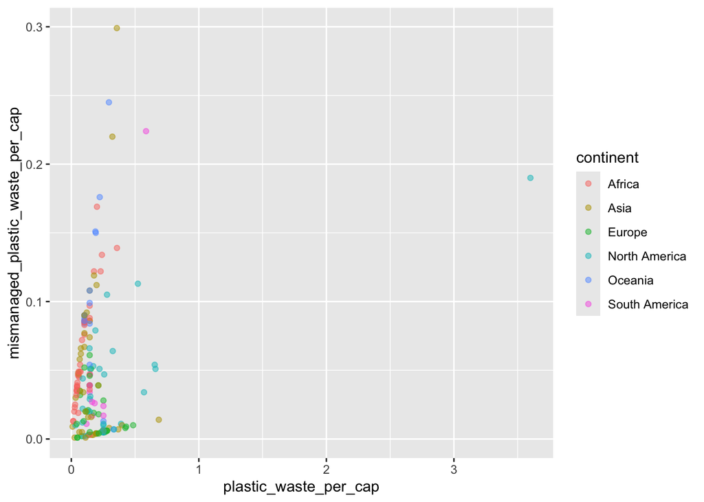

```r
ggplot(data = plastic_waste,
       mapping = aes(x = plastic_waste_per_cap,
                     y = mismanaged_plastic_waste_per_cap,
                     color = continent)) +
  geom_point(alpha = 0.5)
```

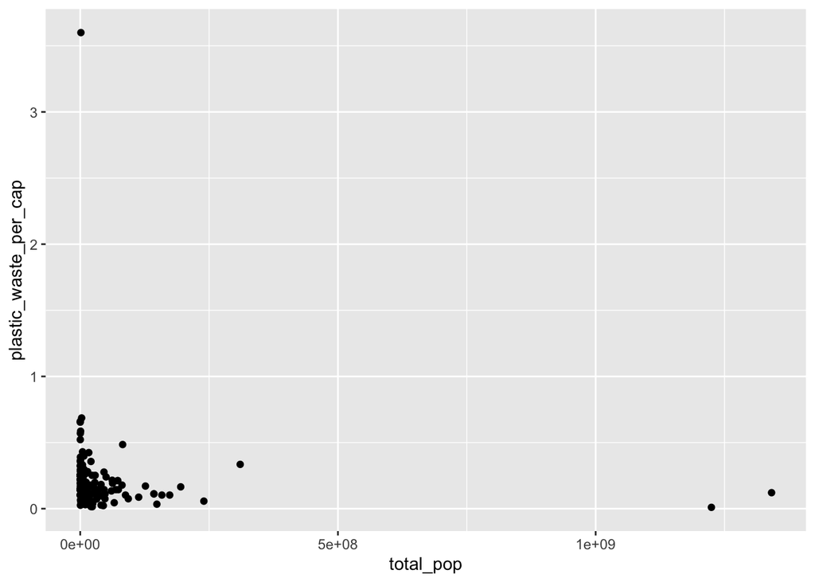

```r
ggplot(data = plastic_waste, mapping = aes(x = total_pop,
                                           y = plastic_waste_per_cap)) +
  geom_point()
```

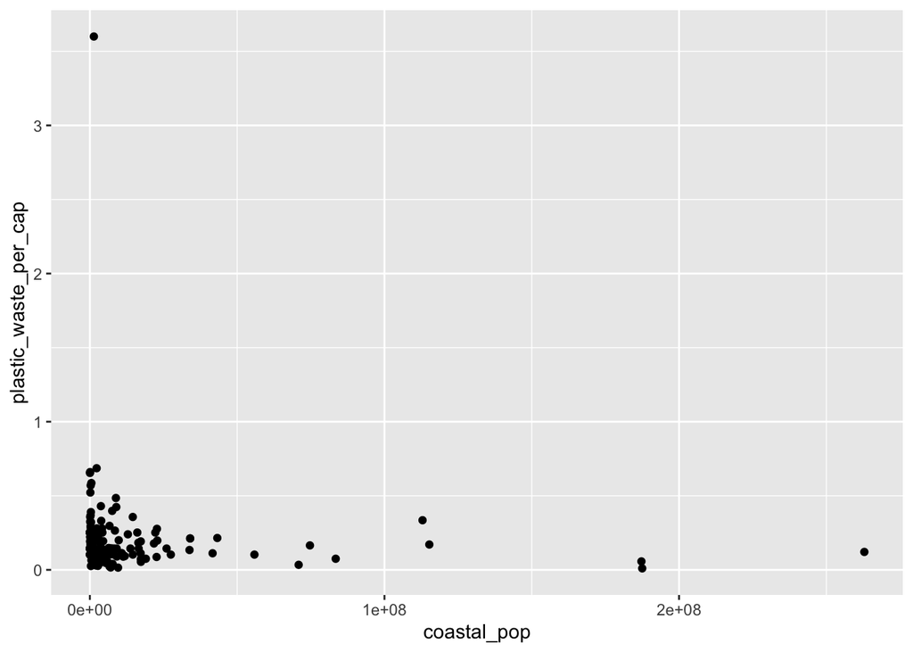

```r
ggplot(data = plastic_waste, mapping = aes(x = coastal_pop,
                                           y = plastic_waste_per_cap)) +
  geom_point()
```

### Exercise 5

Looking at plot 1 below, the general curve shows that the higher the proportion (from 0 to 1), the more plastic waste per capita. There is not much to comment on specific continent, as they are scattered and hard to keep track of. What’s interesting is that some countries have proportions that are higher than 1 which is weird.

Looking at plot 2 below, this graph shows the trend of each continent. All shows a general increase. However, there also seems to be a decrease in trend for some continents.

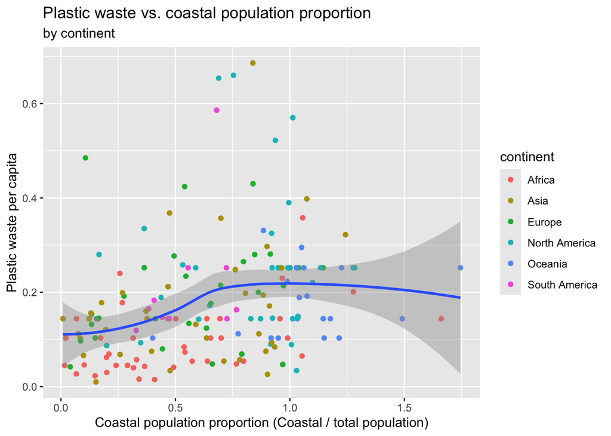

```r
plastic_waste$coastpror = plastic_waste$coastal_pop/plastic_waste$total_pop

ggplot(data = plastic_waste %>%
         filter(plastic_waste_per_cap < 3.5)) +
         geom_point(aes(x = coastpror, y = plastic_waste_per_cap, color = continent)) +
  stat_smooth(aes(x = coastpror, y = plastic_waste_per_cap)) +
         labs(title = "Plastic waste vs. coastal population proportion" ,
                subtitle = "by continent" ,
                x = "Coastal population proportion (Coastal / total population)" ,
                y = "Plastic waste per capita" )
```

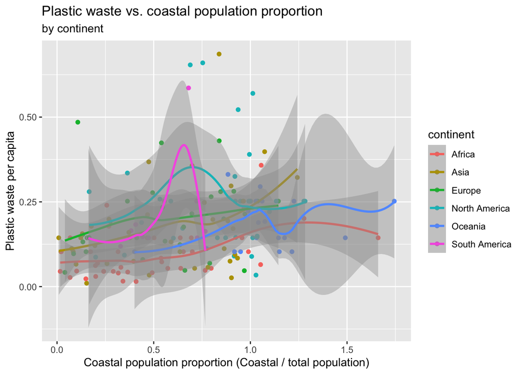

```r
ggplot(data = plastic_waste %>%
         filter(plastic_waste_per_cap < 3.5),
       mapping = aes(x = coastpror, y = plastic_waste_per_cap, color = continent)) +
  geom_point() + stat_smooth() +
         labs(title = "Plastic waste vs. coastal population proportion" ,
                subtitle = "by continent" ,
                x = "Coastal population proportion (Coastal / total population)" ,
                y = "Plastic waste per capita" )
```